# BL40A2030 Wireless Communication Networks

## Week 3 - Assignment

### Author: Jesse Peltola

```python
import sympy as sp
import numpy as np
import scipy.stats as ss
import matplotlib.pyplot as plt
import queue
import copy
from matplotlib import style
style.use('bmh')
#Not to show warning messages (to keep the notebook clean)
import warnings
warnings.filterwarnings('ignore')
```

**1. (M/M/1/K queue) Go to the p. 149 (sectin 7.2) of [this book](http://irh.inf.unideb.hu/user/jsztrik/publications/books/GlobeEdit_Basic_Queueing_Theory_Sztrik_2016.pdf).**

(a) Plot the block probability (probability of the queue is full when a new arrival happens) $P_K$ as a function of $K$ (size of the queue) for $\lambda = 1$ (arrival rate) and $\mu=2$ (service rate). Note that $P_K$ is the probability of having $K$ elements in the system. Use $K$ between 0 and 10.

(b) Plot the expected waiting time in the queue system $\bar{W}$ as a function of $K$ (size of the queue) for $\lambda = 1$ (arrival rate) and $\mu=2$ (service rate). Note that $P_K$ is the probability of having $K$ elements in the system. Use $K$ between 0 and 10.

(c) Discuss the trade-off involved between waiting time and block probability.

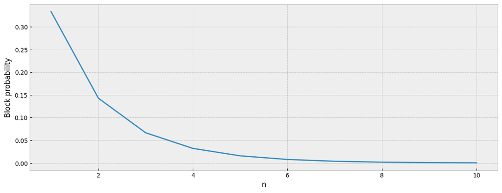

```python
#a)

IAT = 1
ST = 2
rho = IAT/ST

k = 10

P_n = []
for i in range(1, k+1):
    P = ((1-rho)*(rho**i)/(1-rho**(i+1)))
    P_n.append(P)


plt.figure(figsize=(14, 5))
plt.plot(range(1, k+1), P_n)
plt.xlabel("n")
plt.ylabel("Block probability")
plt.show()
```

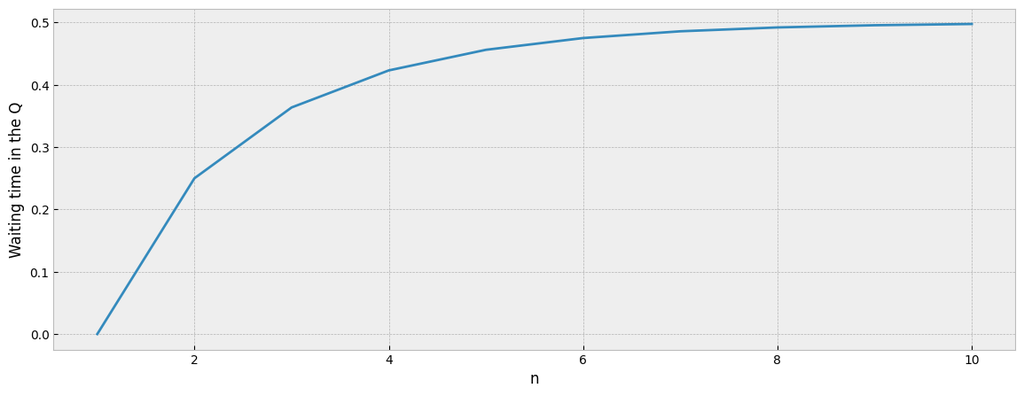

```python
#b)

IAT_rate = 1 #Arrival rate
ST_rate = 2 #Service rate
rho = IAT_rate/ST_rate

k = 10

P_0 = []
L_bar = []
N_bar = []
for i in range(1, k+1):
    P_n.append(((1-rho)*(rho**i)/(1-rho**(i+1))))

for i in range(1, k+ 1):
    P_0.append(((1-rho)*(rho**0)/(1-rho**(i+1))))

for i in range(1, k + 1):
    L_bar.append((rho * (1-(i+1)*rho**i + (i *rho**(i+1))))/((1-rho)*(1-rho**(i+1))))

for i in range(1, k+1):
    N_bar.append((rho * (1-(i+1)*rho**i + i *rho**(i+1)))/((1-rho)*(1-rho**(i+1))))

Q_bar = [None] * 10

for i in range(1, k+1):
    index = i-1
    Q_bar[index] = N_bar[index] - (1 - P_0[index])

W_bar = [x / y for x, y in zip(Q_bar, L_bar)]

plt.figure(figsize=(14, 5))
plt.plot(range(1, k+1), W_bar)
plt.xlabel("n")
plt.ylabel("Waiting time in the Q")
plt.show()
```

**2. ($x$ M/M/1 queues in tandem) Study the network of $x$ queues, a special case of the system presented in Fig. 4.16 in p. 109 from [3]. Consider that the arrival rate is $\lambda$ and the service rate is $\mu$ (the same for all servers) so that $\lambda$ smaller that $\mu$**

- What is the probability that all $x$ queues are empty at the same time as a function of $\lambda$, $\mu$ and $\rho = \lambda/\mu$?

P(0x) = (1-$\rho$) and $\rho_x = \rho = \lambda/\mu$

So P(0_x, 0_1, ..., 0_x) = ... = $(1-\rho)^x$

- Plot this probability as a function of $\lambda$ for $\mu = 3$. Plot in the same figure using the values of $x=1,2,3,4,5$.

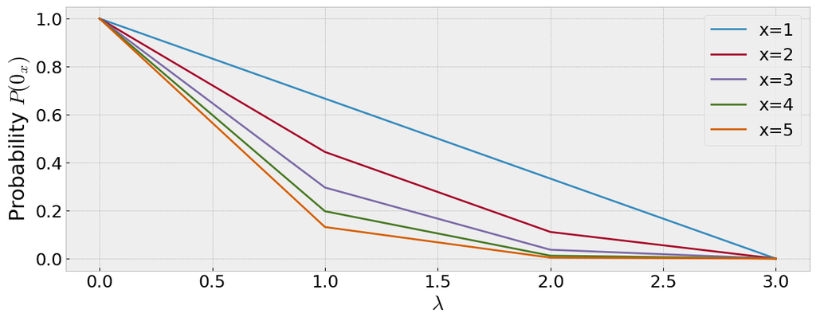

```python
lam = range(0,4)

x_range = range(1,6)
mu =3
series = []
for x in x_range:
    prob = [(1- lamb / mu) ** x for lamb in lam ]
    series.append(prob)

plt.figure(figsize=(14,5))
for x in x_range:
    temp_plt = plt.plot(lam,series[(x-1)], label=f'x={x}' )

plt.legend()
plt.xlabel("$\lambda$")
plt.ylabel("Probability $P(0_x)$")
```

**3. (Optimize Slotted Aloha) In the tutorial, an optimization related to the pure Aloha was presented. Follow the same approach and optimize the Slotted Aloha. Plot the results together with the one presented in the tutorial.**

```python
sp.init_printing()
G = sp.symbols('G')

S = G* sp.exp(-2*G)
S_slot = G * sp.exp(-G)
```

```python
diff_S= sp.diff(S,G)
diff_S_slot = sp.diff(S_slot, G)


opt_G = sp.solve(diff_S, G)
opt_G_slot = sp.solve(diff_S_slot, G)

opt_S = S.subs(G,opt_G[0])
opt_S_slot = S_slot.subs(G, opt_G_slot[0])
display(opt_S)
```

$\displaystyle \frac{1}{2 e}$

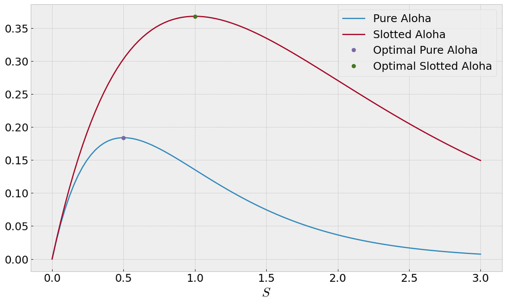

```python
plt.figure(figsize=(14, 8))
plt.rcParams.update({'font.size': 18})

num_G = np.linspace(0, 3, 100)
num_S = num_G * np.exp(-2*num_G)
opt_G = 1/2


num_S_slot = num_G * np.exp(-num_G)

plt.plot(num_G, num_S, '-', label="Pure Aloha")
plt.plot(num_G, num_S_slot, '-', label="Slotted Aloha")
plt.plot(opt_G, opt_S, 'o', label="Optimal Pure Aloha")
plt.plot(opt_G_slot, opt_S_slot, 'o', label="Optimal Slotted Aloha")
plt.xlabel("$G$")
plt.xlabel("$S$")
plt.legend()
plt.show()
```

**4. (Theory) Explain with your own words the basics of the following protocols. Whenever it is possible, compare their differences in terms of throughput, delay and implementation complexity. Use [this slides](http://www.cs.jhu.edu/~cs647/mac_lecture_2.pdf) to help.**

- Pure Aloha
- Slotted Aloha
- CSMA non-persistant
- CSMA 1-persistant
- CSMA p-persistant

Pure Aloha

In Pure Aloha, whenever the nodes has data, they sends it but it may cause collisions. For avoiding collision, the system uses ACK to detect these. It has lower throughput compared to Slotted Aloha due to increased chances of collisions.

Slotted Aloha

The nodes are only allowed to send during their slot which leads to less collision compared to Aloha. It has higher throughput compared to Pure Aloha

CSMA

This protocol, the nodes listens the channel before sending data. It has quite high throughput that minimize the collisions by listening the channel.

CSMA 1-presistent

In this protocol, nodes wait as long as the channel is busy, sending data only after the channel is idle. This has optimal throughput if the channel is lightly loaded.

CSMA p-presistent

This is a extension to CSMA where the nodes wait for a random backoff with a certain probability (p) or transmit with probability (1-p) The throughput of the protocol depends on the chosen probability